# Logoplots

SISBID 2016

Di Cook (dicook@monash.edu, @visnut); Heike Hofmann (heike.hofmann@gmail.com, @heike_hh); edited by Alexej Gossmann

2016-07-14

```r
library(ggplot2)
library(tidyr)
library(dplyr)
library(plyr)
library(lubridate)
library(scales)
library(readr)
library(ggmap)
library(HLMdiag)
library(RColorBrewer)
library(gridExtra)
library(gglogo)
```

## Sequence Logo plots

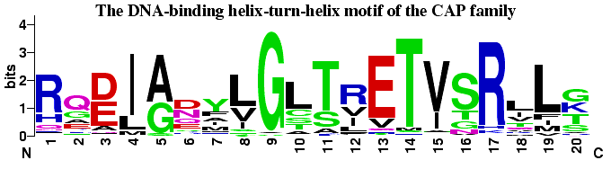

- Logo plots (Schneider & Stephens, 1990) show consensus sequences of aligned DNA or peptide sequences
- various (online) apps to create sequence plots, e.g. [Weblogo 3.0](http://weblogo.berkeley.edu/logo.cgi)
- bit dubious: several design aspects of the plot does not reflect best practice from cognitive perspective

Schneider TD, Stephens RM. Sequence logos: a new way to display consensus sequences. Nucleic Acids Research. 1990;18(20):6097-6100.

## Sequence Logos

- sequences are often distributed in the [FASTA file format](https://en.wikipedia.org/wiki/FASTA_format)
- in R `read.fasta` or `read.alignment(format="fasta")` of the `seqinr` package

```r
library(seqinr)
pfam <- read.fasta(file = "./data/pfam.fasta", as.string=TRUE,
                   seqtype="AA", seqonly=TRUE)
head(pfam, 3)
```

```
#> [[1]]
#> [1] "LTMT.-RGDIGNYLGLTVETISRLLGRFQKLGVL"
#>
#> [[2]]
#> [1] "LTMT.-RGDIGNYLGLTVETISR-----------"
#>
#> [[3]]
#> [1] "LTMT.-RGDIGNYLGLTVETISR-----------"
```

## Construction of Logo plots

In a traditional logo sequence plot:

- x-axis: position of an element,
- y-axis: amount of preserved information (usually Shannon information, in bits)

Shannon information is an entropy measure. Formally, information $I$ in position $p$ is defined as
$$I(p) = \log_2(k) + \sum_{aa} f_{aa} \log_2(f_{aa}),$$
where $f_{aa}$ is the relative frequency of amino acid $aa$ in position $p$ and $k$ is the number of different elements in the sequence ($k = 4$ for RNA/DNA, and $k =21$ for peptide sequences).

For $k = 21$: $I(p)$ is between 0 and $-\log_2 (1/21) = 4.39$ bits, for perfect diversity (0 bits) and single element only (4.39 bits)

## Converting sequences to ggplot2 format

- `ggfortify` processes sequences to a data frame usable in sequence logos in ggplot2 (i.e. introduces `position`, `element`, `info`, …)
- for peptide sequences includes information such as polarity and water properties

```r
library(gglogo)
ggpfam <- ggfortify(data=data.frame(sequences = unlist(pfam)),
                    seq="sequences") %>%
  filter(between(position, 7, 26))
head(ggpfam[order(ggpfam$position),], 3)
```

```
#>    element position freq total       info       bits  Polarity       Water
#> 15       A        7    1   101 0.02469362 0.02469362 non-polar hydrophobic
#> 45       H        7   16   101 0.39509787 0.39509787     basic hydrophobic
#> 50       I        7    1   101 0.02469362 0.02469362 non-polar hydrophobic
```

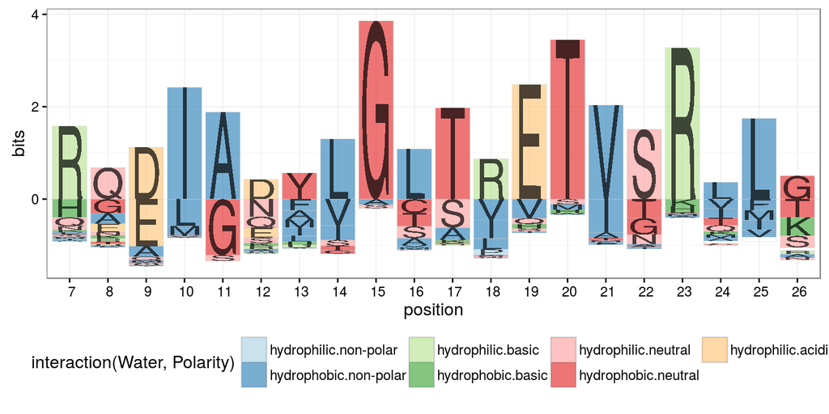

```r
ggplot(data=ggpfam) +
  geom_logo(aes(x = position, label=element, y = bits, fill=interaction(Water, Polarity))) +
  scale_fill_brewer(palette="Paired") +
  theme_bw() +
  theme(legend.position= "bottom")
```

## GeomLogo vs Weblogo

Cognitively, the approach in GeomLogo is better because …

## Positioning of rectangles

- default positioning is `position = "logo"`
- `position = "classic"` stacks the rectangles on top of each other, ordered from largest to smallest. This comes closest to the traditional sequence logo plot
- other positions, such as ‘stack’, ‘fill’, or ‘dodge’ work, but might produce strange output.

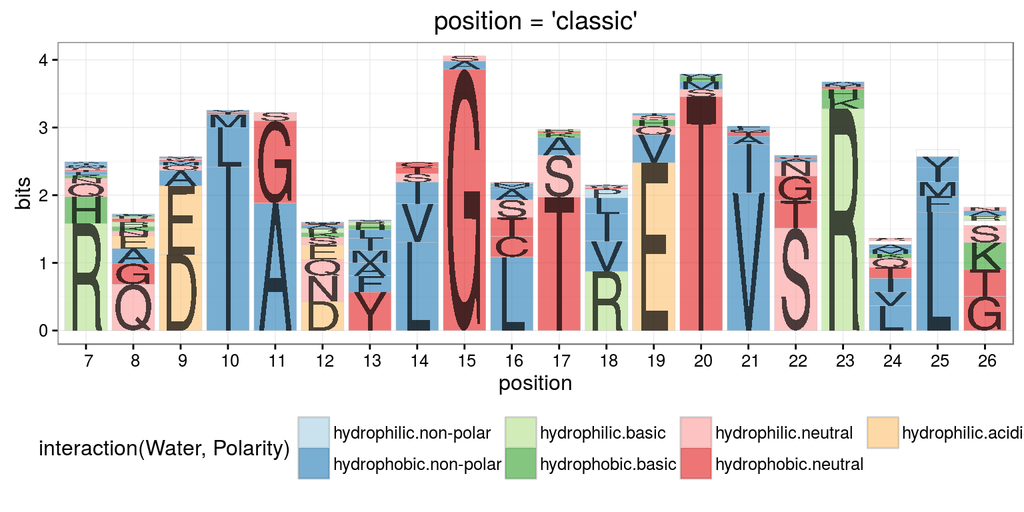

```r
ggplot(data=ggpfam) +
  geom_logo(aes(x = position, label=element, y = bits, fill=interaction(Water, Polarity)), position = 'classic') +
  scale_fill_brewer(palette="Paired") +
  theme_bw() +
  ggtitle("position = 'classic'") +
  theme(legend.position= "bottom")
```

## Another example

- `sequences` data set in gglogo package has additional information on treatment/type: gram positive vs gram negative
- `ggfortify` has parameters `treatment` and `weight`

```r
data(sequences, package = "gglogo")
head(sequences, 3)
```

```
#>                                peptide  class
#> 1 RWTHLASGRTYNYKFNPPKQYGKDDITGEDLIQRED gram -
#> 2 RWTHLNSGRTYHYKFNPPKVHGVDDVTGEPLVQRED gram -
#> 3 RWTHLASGRTYNYKFNPPKQYGKDDITGEDLIQRED gram -
```

```r
ggseq <- ggfortify(data= sequences, seq = "peptide", treatment = .(class))
head(ggseq, 3)
```

```
#>   element  class position freq total        info        bits Polarity
#> 1       . gram -        1    3   923 0.014173689 0.014173689     <NA>
#> 2       . gram +       21   10   886 0.021908523 0.021908523     <NA>
#> 3       . gram -        2    3   923 0.009847968 0.009847968     <NA>
#>   Water
#> 1  <NA>
#> 2  <NA>
#> 3  <NA>
```

## Facetted Logo plots

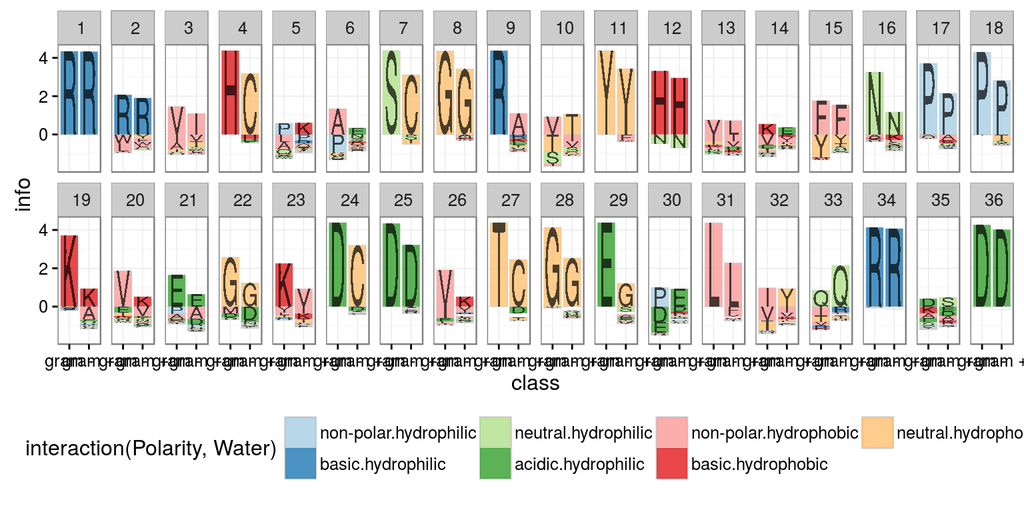

```r
ggplot(data = ggseq) +
  geom_logo(aes(x = class, y = info, label = element, fill=interaction(Polarity, Water)), alpha = 0.8) +
  scale_fill_brewer(palette = "Paired") + facet_wrap(~position, ncol=18) +
  theme_bw() +
  theme(legend.position = "bottom")
```

## Other parameters

- `ggfortify` has parameter `method` - by default, Shannon information is computed, but `method="freq"` computes frequencies
- parameter `alphabet` in `geom_logo` allows to specify polygons from a different font (output from `createPolygons`)

[figure not shown]

```r
if (!exists("alphabet_xkcd"))
  alphabet_xkcd = createPolygons(c(LETTERS), font="xkcd", scale=TRUE)
ggseq2 <- ggfortify(data=sequences, seq="peptide", treatment="class", method="freq")
ggplot(data = ggseq2) +
  geom_logo(aes(x = class, y = freq, label = element, fill=interaction(Polarity, Water)), alpha = 0.8, alphabet=alphabet_xkcd) +
  scale_fill_brewer(palette = "Paired") +
  facet_wrap(~position, ncol=18) +
  ggtitle("logo plot in xkcd font of frequencies") +
  theme_bw() +
  theme(legend.position = "bottom")
```

## Share and share alike

This work is licensed under the Creative Commons Attribution-Noncommercial 3.0 United States License. To view a copy of this license, visit http://creativecommons.org/licenses/by-nc/ 3.0/us/ or send a letter to Creative Commons, 171 Second Street, Suite 300, San Francisco, California, 94105, USA.